# Building a Reccomender System for Manga/Manhua/Manhwa

```python
# Let's see the publications with the highest ratings

df_highest_ratings = df.sort_values(by=['rating'],ascending=False).head(20)

df_highest_ratings
```

|  | title | description | rating | year | tags |
| --- | --- | --- | --- | --- | --- |
| 0 | Salad Days (Tang LiuZang) - Part 2 | The second season of Salad Days (Tang LiuZang). | 4.7 | 2021.0 | ['BL', 'Manhua', 'Romance', 'Shounen-ai', 'Spo... |
| 29 | GTO | With a history of leading a motorcycle gang an... | 4.7 | 1996.0 | ['Comedy', 'Drama', 'Ecchi', 'Shounen', 'Delin... |
| 21 | Your Letter | Sori is a special young girl - kind, caring an... | 4.7 | 2018.0 | ['Adventure', 'Drama', 'Manhwa', 'Mystery', 'W... |
| 22 | Only I Level Up (Novel) | In this world where Hunters with various magic... | 4.7 | 2016.0 | ['Action', 'Adventure', 'Fantasy', 'Manhwa', '... |
| 23 | Bloom Into You | Yuu has always loved shoujo manga and awaits t... | 4.7 | 2015.0 | ['Drama', 'GL', 'Romance', 'Shoujo-ai', 'Shoun... |
| 24 | The Male Lead's Little Lion Daughter | The handsome Duke Voreoti is the most terrifyi... | 4.7 | 2021.0 | ['Comedy', 'Drama', 'Fantasy', 'Manhwa', 'Roma... |
| 25 | 20th Century Boys | The world is never quite the same once we grow... | 4.7 | 1999.0 | ['Action', 'Drama', 'Mystery', 'Sci Fi', 'Sein... |
| 26 | Vagabond | Following a horrific defeat at the battle of S... | 4.7 | 1998.0 | ['Action', 'Adventure', 'Drama', 'Seinen', '17... |
| 27 | Roxana | Kidnapping, murder, and risqué relationships! ... | 4.7 | 2021.0 | ['Drama', 'Fantasy', 'Manhwa', 'Romance', 'Web... |
| 30 | Level Up with the Gods | “Maybe Inner Gods can never defeat Outer Gods…... | 4.7 | 2021.0 | ['Action', 'Adventure', 'Fantasy', 'Manhwa', '... |
| 19 | Our Dreams at Dusk: Shimanami Tasogare | Not only is high schooler Tasuku Kaname the ne... | 4.7 | 2015.0 | ['Drama', 'Seinen', 'LGBT Themes', 'Psychologi... |
| 31 | Kaguya-sama: Love Is War | As leaders of their prestigious academy’s stud... | 4.7 | 2015.0 | ['Comedy', 'Drama', 'Romance', 'Seinen', 'Epis... |
| 32 | Sign | There are a few unusual things about Cafe Goyo... | 4.7 | 2017.0 | ['BL', 'Comedy', 'Manhwa', 'Romance', 'Slice o... |
| 33 | Three Days of Happiness (Light Novel) | In this dark, moody love story, college studen... | 4.7 | 2013.0 | ['Drama', 'Light Novels', 'Romance', 'Slice of... |
| 34 | The Legend of the Northern Blade | For decades, the brave warriors of the Norther... | 4.7 | 2019.0 | ['Action', 'Adventure', 'Fantasy', 'Manhwa', '... |
| 35 | The Horizon | Two children unexpectedly meet in the midst of... | 4.7 | 2016.0 | ['Drama', 'Manhwa', 'Webtoons', 'Melancholy', ... |
| 36 | Skip Beat! | Kyoko moves to the big city with the prince of... | 4.7 | 2002.0 | ['Comedy', 'Drama', 'Romance', 'Shoujo', 'Slic... |
| 1 | The Master of Diabolism | As the grandmaster who founded the Demonic Sec... | 4.7 | 2017.0 | ['Action', 'Adventure', 'BL', 'Comedy', 'Manhu... |
| 20 | Spirit Fingers! | What do you do if you're going on 18, totally ... | 4.7 | 2015.0 | ['Comedy', 'Manhwa', 'Romance', 'Webtoons', 'F... |
| 28 | Nano Machine | After being held in disdain and having his lif... | 4.7 | 2020.0 | ['Action', 'Adventure', 'Fantasy', 'Manhwa', '... |

The results are interesting because I only recognize 3 titles in the top 20 highest rated manga. Although, that may be because I don't read manga much--I mainly read manhua and manhwa, but one of the titles I do recognize is Roxana. I was suprised it made it into the list because it's a relatively new manhwa, and definitely not as popular as the popular manhwas(such as Who Made Me a Princess). So, I think some publications with high ratings simply have high ratings because they're not as popular so less users are rating them, and as a result the rating is an average rating of users that like the manga, and not necessarily indicative of the manga's quality. Roxana, in my opinion, does not deserve a 4.7(it's not that it's not a good manhwa, but given how sparingly 4.7s are given out, I don't think it on-par with the selectivity that this rating implies). So a reccomender system that just spits out the highest rated entries would not be very useful, because of the factors that affect a publication's rating is not necessarily due to the quality of the actual publication. I think, to make the ratings more accurate, I would need access to how many users submitted a rating to achieve that rating for a publication.

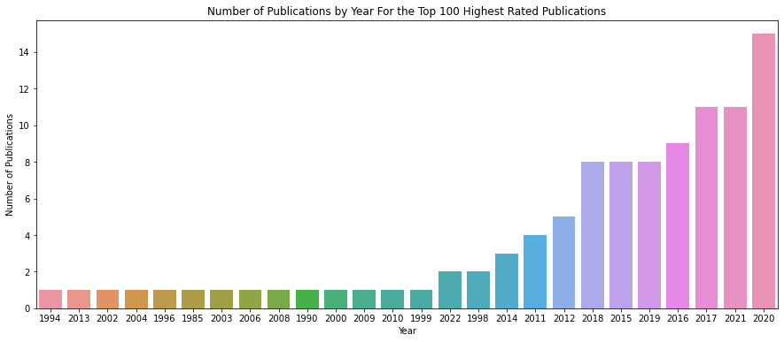

```python
# With this, and with the possible limitations of ratings in mind, let's still explore the top 100 highest rated publications anyway.

# Gets the entries with the top 100 ratings
df_highest_ratings_100 = df.sort_values(by=['rating'],ascending=False).head(100)

# Let's see when the top 100 publications were published

# dropping entries where there are missing values in the year column
df_highest_ratings_100 = df_highest_ratings_100.dropna(subset=['year'])

# Removing the decimal point in the year values by converting the year floats to ints
df_highest_ratings_100['year'] = df_highest_ratings_100['year'].apply(np.int64)

# Gives us a series where the index of the series is the year value, and the data is the count of how many entries in df has that year
# Basically tells us the number of publications for each year
pubByYearSeries = df_highest_ratings_100['year'].value_counts()

# Creates a dataframe using the index of the pubByYearSeries to populate the Year and the values as the Number of Publications col
pubByYear = pd.DataFrame({'Year':pubByYearSeries.index, 'Number of Publications':pubByYearSeries.values})

fig, ax = plt.subplots()

sns.barplot(x="Year", y="Number of Publications", data=pubByYear, ax=ax, order=pubByYear.sort_values('Number of Publications').Year).set(title='Number of Publications by Year For the Top 100 Highest Rated Publications')

fig.set_size_inches(15, 6)

# From the bar plot we can see that the most of the publications with high ratings came from 2020, then 2017 and 2021.
```

#### What are the Most Common Genre/Tags?

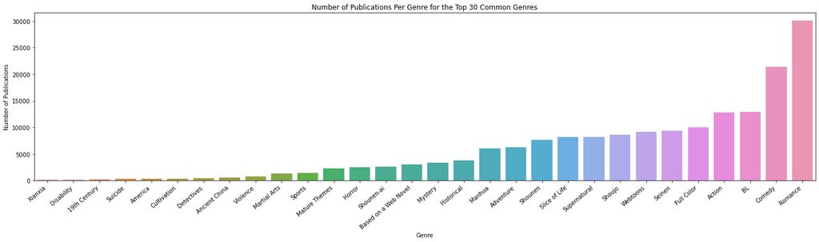

```python
# Dropping rows in the df where the tags are missing
tagsCol = df.dropna(subset=['tags'])

# Get the tags column
tagsCol = df.loc[:,"tags"]

# dictionary where the key is the tag/genre, and the values are the count of how many times that genre appears in the df
tagsCount = {}

# Loop through each entry in the tagCol, where each entry is a list of tags. For each value in the list of tags,
# if it's already in tagsCount, I increment the value associated with that key/tag/genre by 1. If not, I set it to 1.
for tags in tagsCol:
    # each entry is actually a stringified list, so to convert it back to an actual list I use literal_eval
    tags = literal_eval(tags)
    for tag in tags:
        tagsCount[tag] = 1 + tagsCount.get(tag, 0)

# Create a df using the tagsCount dictionary. The df will contain a genre column, and a "Number of Publications" col,
# which represents how many times that genre showed up inside the tags list of an entry inside the dataframe
pubByGenre = pd.DataFrame({'Genre':tagsCount.keys(), 'Number of Publications':tagsCount.values()})

fig, ax = plt.subplots()

sns.barplot(x="Genre", y="Number of Publications", data=pubByGenre[:30], ax=ax, order=pubByGenre[:30].sort_values('Number of Publications').Genre).set(title='Number of Publications Per Genre for the Top 30 Common Genres')

fig.set_size_inches(20, 6)

ax.set_xticklabels(ax.get_xticklabels(), rotation=40, ha="right")
plt.tight_layout()
plt.show()
```

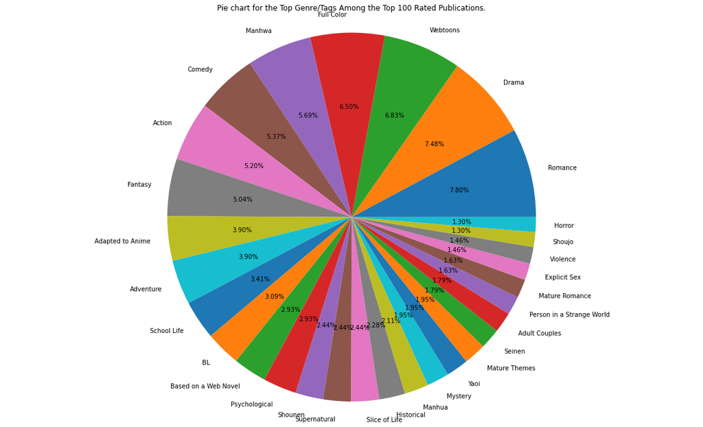

```python
# Let's see what genre's are most common in publications with the highest ratings. I imagine it would be similar to the graph that
# shows us the most common genres overall, because authors would be inclined to produce publications that are in-demand.

# Dropping rows in the df where the tags are missing. We're using the df_highest_ratings_100 df that we made earlier, which contains
# the top 100 entries with the highest ratings
tagsCol = df_highest_ratings_100.dropna(subset=['tags'])

# Get the tags column
tagsCol = df_highest_ratings_100.loc[:,"tags"]

# dictionary where the key is the tag/genre, and the values are the count of how many times that genre appears in the df
tagsCount = {}

# Loop through each entry in the tagCol, where each entry is a list of tags. For each value in the list of tags,
# if it's already in tagsCount, I increment the value associated with that key/tag/genre by 1. If not, I set it to 1.
for tags in tagsCol:
    # each entry is actually a stringified list, so to convert it back to an actual list I use literal_eval
    tags = literal_eval(tags)
    for tag in tags:
        tagsCount[tag] = 1 + tagsCount.get(tag, 0)

# Sort the dictionary in descending order based on values, so we can get the genre with the highest counts at the beginning of the dict
sortedTagsCount = dict(sorted(tagsCount.items(),key=operator.itemgetter(1),reverse=True))

# We only want the 30 most common tags/genres
# Create a sliced dictionary
# dict() is used to convert the iterable result of itertools.islice() to a new dictionary
sortedTagsCount = dict(itertools.islice(sortedTagsCount.items(), 0 , 30))

# Create an axis object
fig, ax = plt.subplots(1, 1, figsize = (20, 12))

# Get the data in the right format
labels = list(sortedTagsCount.keys())
sizes  = list(sortedTagsCount.values())

# Plot the pie chart
ax.pie(sizes, labels = labels, shadow = False, startangle = 0, autopct = "%1.2f%%")
ax.axis('equal')
ax.set_title(f"Pie chart for the Top Genre/Tags Among the Top 100 Rated Publications.")

plt.show()
```

### Part 4: Generating the Recommender System

##### [Recommendation Systems](https://www.engati.com/glossary/recommendation-systems) are computer programs that suggest recommendations to users depending on some criteria. For my recommendation system, I will be using content-based filtering, which suggests recommendations based on the item metadata. The main idea is if a user likes an item, then the user will also like items similar to it.

### Recommender System Using Tags

```python
# I will be using the title and tags column as features to build the recommendation system.

# Currently just using the tags column to build the system. If there is time I'll incorporate the description and/or title column.

# Dropping entries where there are missing values in the description or tags column
# Only using the first 5000 entries because the Jupyter kernel dies with too many entries
mangas_df = df.dropna(subset=['tags', 'title']).head(5000)

# We'll be using the tag feature/column to generate the recommender
features = ["tags"]

# cleaning the data by converting everything to lowercase and removing spaces
for feature in features:
    mangas_df[feature] = mangas_df[feature].str.replace(' ','').str.lower()

# The ast.literal_eval method can safely evaluate strings containing Python values from unknown sources without us having to parse the values.
for feature in features:
    mangas_df[feature] = mangas_df[feature].apply(literal_eval)

# create a soup containing the metadata extracted from the input to be put into the vectorizer
def create_soup(features):
    return ' '.join(features['tags'])

mangas_df["soup"] = mangas_df.apply(create_soup, axis=1)

print(mangas_df["soup"].head())
```

```
0    bl manhua romance shounen-ai sports webtoons f...
1    action adventure bl comedy manhua mystery roma...
2    action adventure horror mystery seinen 19thcen...
3                romance shoujo sliceoflife disability
4    mystery shounen detectives england europe hist...
Name: soup, dtype: object
```

```python
# Our manga recommendation engine works by suggesting mangas to the user based on the metadata information.
# The similarity between the mangas  is calculated and then used to make recommendations.

# CountVectorizer counts the frequency of each word and outputs a 2D vector containing frequencies.
count_vectorizer = CountVectorizer(stop_words="english")
count_matrix = count_vectorizer.fit_transform(mangas_df["soup"])

#print(count_matrix.shape)

# we use the cosine similarity score as this is just the dot product of the vector output by the CountVectorizer.
cosine_sim2 = cosine_similarity(count_matrix, count_matrix)
#print(cosine_sim2.shape)

# Creates a series where the title is mapped to index of the mangas_df.
# Using this, we can find the title of the movie based on the index.
indices = pd.Series(mangas_df.index, index=mangas_df["title"]).drop_duplicates()
```

```python
indices
```

```
title
Salad Days (Tang LiuZang) - Part 2                    0
The Master of Diabolism                               1
JoJo's Bizarre Adventure Part 7: Steel Ball Run       2
A Sign of Affection                                   3
Moriarty the Patriot                                  4
                                                   ...
Magician                                           4995
Yura-kun no 10% ni wa Himitsu ga Aru               4996
Touta                                              4997
Patissier-san to Oujo-san                          4998
I Hate You More Than Anyone                        4999
Length: 5000, dtype: int64
```

```python
# Function that returns 10 recommendations given the title of a manga
def get_recommendations(title, cosine_sim=cosine_sim2):
    # gets the index into the mangas_df using the title
    idx = indices[title]
    # Get the list of similarity scores of the manga concerning all the mangas in the df
    # Create tuples with the first element being the index and the second element is the cosine similarity score
    # (a, b) where a is index of manga, b is similarity_scores
    similarity_scores = list(enumerate(cosine_sim[idx]))

    # Sort the list of tuples in descending order based on the similarity score.
    similarity_scores = sorted(similarity_scores, key=lambda x: x[1], reverse=True)

    # We get the top 10 entries from the sorted list of tuples. Excluding the 0th element bc that's the original manga itself
    similarity_scores = similarity_scores[1:11]

    # Extracting the index value of the mangas from the tuples
    mangas_indices = [ind[0] for ind in similarity_scores]

    # Using the index to index into the mangas_df to retrieve the name of the similar mangas
    mangas = mangas_df["title"].iloc[mangas_indices]
    return mangas

print("Roxana")
print(get_recommendations("Roxana", cosine_sim2))
```

```
Roxana
1302                    Becoming the Dark Hero's Daughter
3481                    The Little Lady Behind the Scenes
4463                              Happily Ever Afterwards
1195                                     Marry My Husband
643                         I Married the Male Lead's Dad
4439                          Villain Duke's Precious One
4762    A Tender Heart: The Story of How I Became a Du...
4780                                The Viridescent Tiara
24                   The Male Lead's Little Lion Daughter
607     Please Don’t Come To The Villainess’ Stationer...
Name: title, dtype: object
```

##### The recommender appears to be working as expected. Roxana is a manhwa in the villainess genre, and although I don't recognize any titles that were recommended, just looking at the titles of the mangas, they appear to be similar to Roxana.

### Part 5: Conclusions and Further Exploration

In this tutorial, we explored the Anime-Planet dataset on mangas using using the data science pipeline and generated a recommender system using this dataset. As a result of my analysis, I found some suprising results, such as what the most common genre/tags of mangas are, what years were the most mangas published, and what genre/tags are associated with the highest rated titles. On the other hand, while doing my analysis, I also noticed the limitations of this dataset--because high ratings does not necessarily indicate popularity or quality of the manga. A dataset that includes the number of views for a particular publication would be a better indicator of popularity/quality than ratings, because as I mentioned before, some publications may just have high ratings because not many users have rated it. Consequently, that's a factor we need to keep in mind when interpreting the results of this dataset. So further exploration would include finding a dataset that also include views for mangas and merging it with this dataframe. As for the recommender system, I thought the best type of recommender system for this dataset would be a content based one, because it just intuively makes sense, a reader would be inclined to like mangas that are similar to each other. If we could find user data and use that in tandem with our current dataset, we could possibly build a system that is generated by analyzing the user's behavior and the demographics of users similar to each other. Lastly, for my recommender system, I only used the tags to generate the words to feed into the CountVectorizers, but to make the recommender more tailored, we could possibly also include the title and description of the manga as well. Although that may lead to overfitting, but we'll have to see.

References: I used this [Towards Data Science tutorial on anime data](https://towardsdatascience.com/exploratory-data-analysis-on-anime-data-468cc15e13b8) to guide my exploratory data analysis. I used [this tutorial](https://techvidvan.com/tutorials/movie-recommendation-system-python-machine-learning/) as a reference to build the recommendation system.